# Time Series Forecasting: Europe Brent Spot Price FOB

Enrique Pérez Herrero

January 9, 2017 (updated October 26, 2026)

# 1 SUMMARY

Europe Brent Spot Price FOB (Dollars per Barrel) https://www.eia.gov/dnav/pet/hist/LeafHandler.ashx?n=PET&s=rbrte&f=D

Monthly mean prices are modelled with ARIMA and ETS on the log scale and compared with the random walk (naive) forecast, the usual benchmark for oil prices (Alquist, Kilian and Vigfusson, 2011), on a 24 month test set and with rolling origin cross-validation. The ARIMA model selected with all the data gives the forecast for the next 12 months.

# 2 LOAD DATA

## 2.1 Load Packages

```r
library(plotly)
library(forecast)
library(tseries)
library(ggplot2)
source("R/brent.R")
```

## 2.2 Download and Read Data

The EIA Excel file is downloaded again if the local copy is older than a week.

```r
download_brent()
brent_daily <- read_brent()
brent <- monthly_brent(brent_daily)
```

Daily data from 1987-05-20 to 2026-10-20 (9112 observations), 473 complete months.

```r
summary(brent_daily)
```

```
##      Index              USD_Barrel
##  Min.   :1987-05-20   Min.   :  9.10
##  1st Qu.:1998-02-01   1st Qu.: 20.60
##  Median :2008-10-14   Median : 52.58
##  Mean   :2007-11-25   Mean   : 54.51
##  3rd Qu.:2017-10-20   3rd Qu.: 77.51
##  Max.   :2026-10-20   Max.   :143.95
```

# 3 EXPLORATORY ANALYSIS

## 3.1 Daily Prices

```r
brent_df <- data.frame(Date = index(brent_daily),
                       USD_Barrel = as.numeric(brent_daily))

plot_ly(data = brent_df,
        x = ~Date,
        y = ~USD_Barrel,
        type = "scatter",
        mode = "lines") %>%
  layout(title = "Europe Brent Spot Price FOB",
         xaxis = list(title = ""),
         yaxis = list(title = "Price (USD/Barrel)")
         )
```

[interactive chart not shown]

## 3.2 Prices Histogram

```r
plot_ly(data = brent_df,
        x = ~USD_Barrel,
        type = "histogram") %>%
  layout(title = "Daily Prices Histogram",
         xaxis = list(title = "Price (USD/Barrel)")
  )
```

[interactive chart not shown]

## 3.3 Monthly Prices

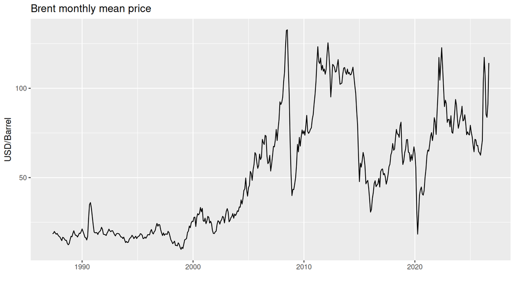

```r
autoplot(brent) +
  labs(title = "Brent monthly mean price", x = "", y = "USD/Barrel")
```

## 3.4 STL Decomposition

Variance grows with the price level, so the decomposition is done on `log(price)`.

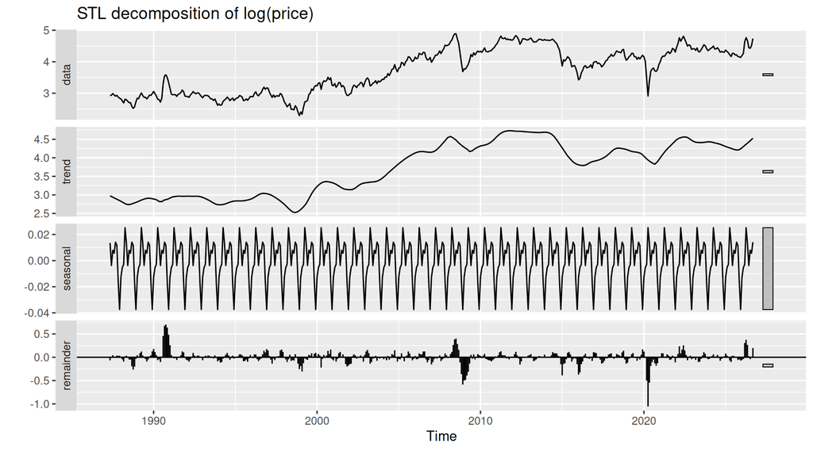

```r
autoplot(stl(log(brent), s.window = "periodic", robust = TRUE)) +
  labs(title = "STL decomposition of log(price)")
```

The seasonal component is very small compared with the trend and the remainder.

# 4 STATIONARITY

Augmented Dickey-Fuller (H0: unit root) and KPSS (H0: stationary) tests on the log prices and on the monthly log returns.

```r
log_brent <- log(brent)
returns <- diff(log_brent)

stationarity <- function(x) {
  c(ADF_p = adf.test(x)$p.value, KPSS_p = kpss.test(x)$p.value)
}

round(rbind(`log(price)` = stationarity(log_brent),
            `diff(log(price))` = stationarity(returns)), 3)
```

```
##                  ADF_p KPSS_p
## log(price)       0.318   0.01
## diff(log(price)) 0.010   0.10
```

```r
ndiffs(log_brent)
```

```
## [1] 1
```

```r
nsdiffs(log_brent)
```

```
## [1] 0
```

Log prices have a unit root; one difference makes the series stationary.

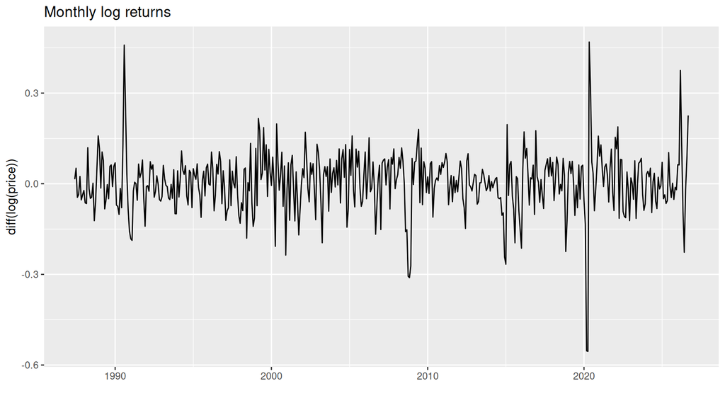

```r
autoplot(returns) +
  labs(title = "Monthly log returns", x = "", y = "diff(log(price))")
```

## 4.1 ACF and PACF of Returns

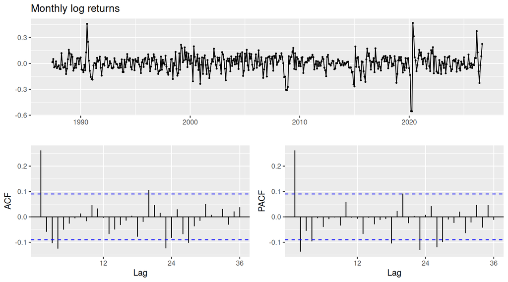

```r
ggtsdisplay(returns, main = "Monthly log returns")
```

# 5 MODELS

## 5.1 Train and Test Sets

The last 24 months are kept as test set.

```r
h_test <- 24
train <- head(brent, length(brent) - h_test)
test <- tail(brent, h_test)
```

## 5.2 Fit Models

All models are fitted on the log scale (`lambda = 0`) and back-transformed with bias adjustment.

```r
fit_arima <- auto.arima(train, lambda = 0, biasadj = TRUE,
                        stepwise = FALSE, approximation = FALSE)
fit_ets <- ets(train, lambda = 0, biasadj = TRUE)
fit_arima
```

```
## Series: train
## ARIMA(1,1,2)
## Box Cox transformation: lambda= 0
##
## Coefficients:
##          ar1      ma1      ma2
##       0.8815  -0.6062  -0.3142
## s.e.  0.0611   0.0709   0.0451
##
## sigma^2 = 0.008917:  log likelihood = 422.96
## AIC=-837.92   AICc=-837.83   BIC=-821.5
```

```r
fit_ets
```

```
## ETS(A,N,N)
##
## Call:
## ets(y = train, lambda = 0, biasadj = TRUE)
##
##   Box-Cox transformation: lambda= 0
##
##   Smoothing parameters:
##     alpha = 0.9999
##
##   Initial states:
##     l = 2.9224
##
##   sigma:  0.0989
##
##      AIC     AICc      BIC
## 668.1924 668.2463 680.5135
```

```r
fc <- list(
  Naive = rwf(train, h = h_test, lambda = 0, biasadj = TRUE),
  Drift = rwf(train, h = h_test, drift = TRUE, lambda = 0, biasadj = TRUE),
  ETS = forecast(fit_ets, h = h_test),
  ARIMA = forecast(fit_arima, h = h_test)
)
```

## 5.3 Test Set Accuracy

```r
test_accuracy <- t(sapply(fc, function(f) accuracy(f, test)["Test set", ]))
knitr::kable(test_accuracy[, c("RMSE", "MAE", "MAPE", "MASE")], digits = 3)
```

|  | RMSE | MAE | MAPE | MASE |
| --- | --- | --- | --- | --- |
| Naive | 14.599 | 10.993 | 13.328 | 0.827 |
| Drift | 14.115 | 11.353 | 14.506 | 0.854 |
| ETS | 14.597 | 10.993 | 13.330 | 0.827 |
| ARIMA | 14.836 | 11.536 | 14.273 | 0.868 |

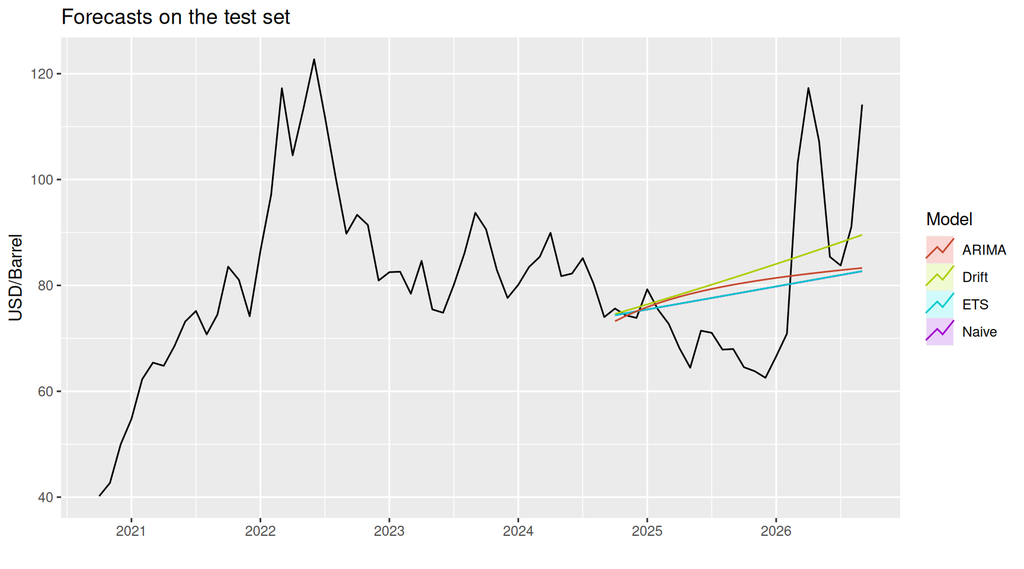

```r
autoplot(window(brent, start = time(test)[1] - 4)) +
  autolayer(fc$Naive, series = "Naive", PI = FALSE) +
  autolayer(fc$Drift, series = "Drift", PI = FALSE) +
  autolayer(fc$ETS, series = "ETS", PI = FALSE) +
  autolayer(fc$ARIMA, series = "ARIMA", PI = FALSE) +
  labs(title = "Forecasts on the test set", x = "", y = "USD/Barrel",
       colour = "Model")
```

## 5.4 Time Series Cross-Validation

A single test set depends a lot on what happened in those 24 months. Rolling origin evaluation since 2005 compares ARIMA (with the order chosen above) and the naive forecast for horizons of 1 to 12 months.

```r
h_cv <- 12
order <- arimaorder(fit_arima)
seasonal <- if (length(order) > 3) order[4:6] else c(0, 0, 0)
arima_cv <- function(y, h) {
  forecast(Arima(y, order = order[1:3], seasonal = seasonal,
                 include.drift = "drift" %in% names(coef(fit_arima)),
                 lambda = 0, biasadj = TRUE), h = h)
}
naive_cv <- function(y, h) rwf(y, h = h, lambda = 0, biasadj = TRUE)

initial <- sum(time(brent) < 2005)
e_arima <- tsCV(brent, arima_cv, h = h_cv, initial = initial)
e_naive <- tsCV(brent, naive_cv, h = h_cv, initial = initial)

cv_rmse <- data.frame(
  h = 1:h_cv,
  ARIMA = sqrt(colMeans(e_arima^2, na.rm = TRUE)),
  Naive = sqrt(colMeans(e_naive^2, na.rm = TRUE))
)
knitr::kable(cv_rmse, digits = 2, row.names = FALSE)
```

| h | ARIMA | Naive |
| --- | --- | --- |
| 1 | 6.74 | 7.12 |
| 2 | 11.28 | 11.56 |
| 3 | 14.55 | 14.65 |
| 4 | 16.81 | 16.83 |
| 5 | 18.67 | 18.68 |
| 6 | 20.40 | 20.39 |
| 7 | 21.91 | 21.89 |
| 8 | 23.13 | 23.09 |
| 9 | 24.28 | 24.22 |
| 10 | 25.24 | 25.18 |
| 11 | 26.19 | 26.09 |
| 12 | 27.11 | 26.94 |

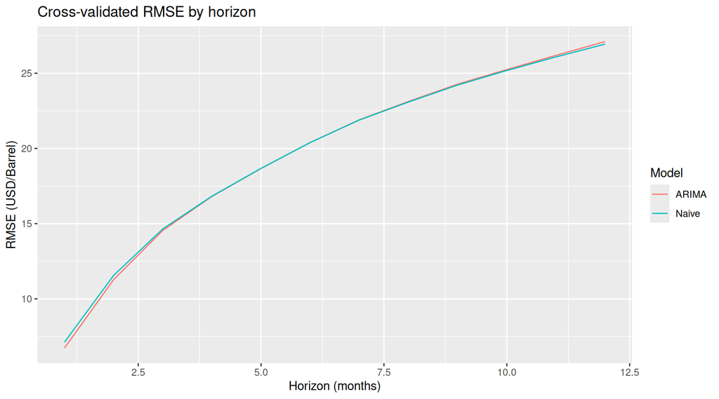

```r
ggplot(cv_rmse, aes(x = h)) +
  geom_line(aes(y = ARIMA, colour = "ARIMA")) +
  geom_line(aes(y = Naive, colour = "Naive")) +
  labs(title = "Cross-validated RMSE by horizon", x = "Horizon (months)",
       y = "RMSE (USD/Barrel)", colour = "Model")
```

# 6 FORECAST

## 6.1 Final Model

The ARIMA model is selected again with all the data.

```r
fit <- auto.arima(brent, lambda = 0, biasadj = TRUE,
                  stepwise = FALSE, approximation = FALSE)
fit
```

```
## Series: brent
## ARIMA(1,1,2)
## Box Cox transformation: lambda= 0
##
## Coefficients:
##          ar1      ma1      ma2
##       0.8750  -0.5953  -0.3217
## s.e.  0.0606   0.0690   0.0433
##
## sigma^2 = 0.009022:  log likelihood = 442.75
## AIC=-877.5   AICc=-877.42   BIC=-860.87
```

## 6.2 Residuals

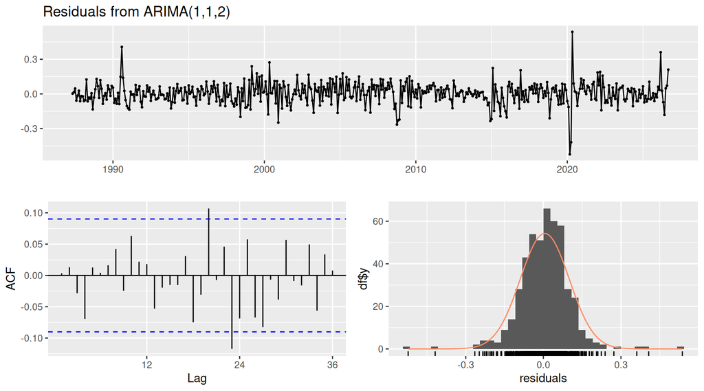

```
##
##  Ljung-Box test
##
## data:  Residuals from ARIMA(1,1,2)
## Q* = 27.97, df = 21, p-value = 0.141
##
## Model df: 3.   Total lags used: 24
```

```r
checkresiduals(fit)
```

## 6.3 Next 12 Months

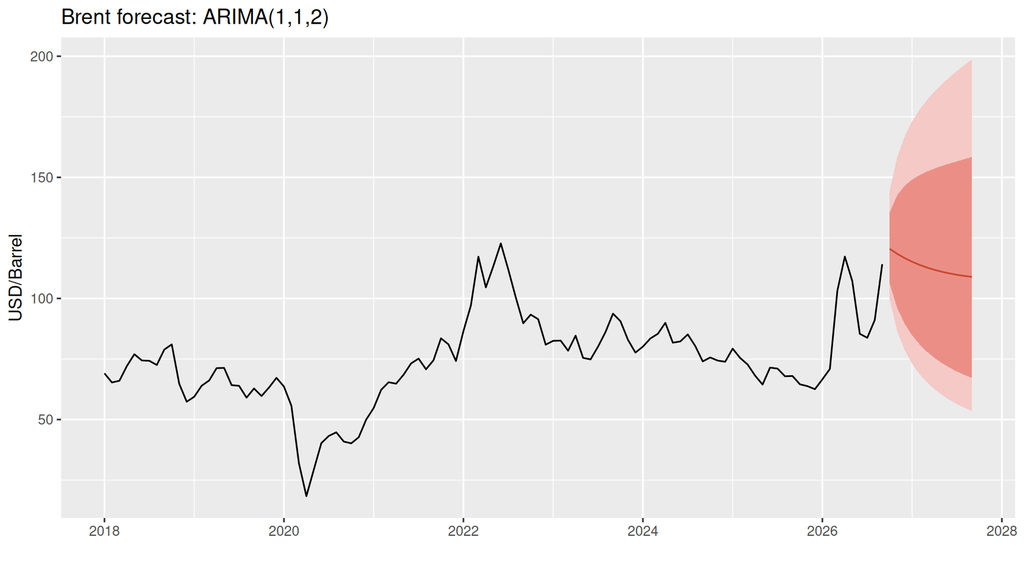

```r
brent_fc <- forecast(fit, h = 12)

autoplot(window(brent, start = end(brent)[1] - 8)) +
  autolayer(brent_fc, series = "ARIMA") +
  labs(title = paste("Brent forecast:", as.character(fit)),
       x = "", y = "USD/Barrel") +
  theme(legend.position = "none")
```

```r
knitr::kable(as.data.frame(brent_fc), digits = 2)
```

|  | Point Forecast | Lo 80 | Hi 80 | Lo 95 | Hi 95 |
| --- | --- | --- | --- | --- | --- |
| Oct 2026 | 120.48 | 106.19 | 135.47 | 99.57 | 144.48 |
| Nov 2026 | 118.43 | 96.04 | 142.62 | 86.50 | 158.35 |
| Dec 2026 | 116.66 | 89.57 | 146.50 | 78.63 | 166.88 |
| Jan 2027 | 115.15 | 84.78 | 149.07 | 73.02 | 173.08 |
| Feb 2027 | 113.85 | 81.02 | 150.95 | 68.72 | 177.97 |
| Mar 2027 | 112.74 | 77.97 | 152.42 | 65.29 | 182.01 |
| Apr 2027 | 111.80 | 75.43 | 153.65 | 62.48 | 185.49 |
| May 2027 | 111.00 | 73.27 | 154.72 | 60.12 | 188.56 |
| Jun 2027 | 110.33 | 71.43 | 155.70 | 58.11 | 191.36 |
| Jul 2027 | 109.76 | 69.82 | 156.62 | 56.38 | 193.95 |
| Aug 2027 | 109.30 | 68.41 | 157.50 | 54.86 | 196.40 |
| Sep 2027 | 108.91 | 67.17 | 158.37 | 53.52 | 198.73 |

The 95 % interval is wide: as with most financial series, the monthly returns are close to white noise and the point forecast stays near the last price. Cross-validation shows how much (or how little) ARIMA improves on the random walk.

# 7 LINKS

- [4-Plot](http://www.itl.nist.gov/div898/handbook/eda/section3/4plot.htm)
- [Forecasting: Principles and Practice (2nd ed.)](https://otexts.com/fpp2/)
- [R in Time Series: Autocorrelation in R](http://quantlego.com/howto/autocorrelation-in-r/)
- [Forecasting Brent Oil](https://rstudio-pubs-static.s3.amazonaws.com/71505_b67043c08a5f48c2b5797fab525401cb.html)
- [Oil Series in R](http://kukuruku.co/hub/r/oil-series-oil-prices-in-r)
- [Plotting Forecast Objects](https://plot.ly/r/graphing-multiple-chart-types/#plotting-forecast-objects)
- [CRAN Task View: Time Series Analysis](https://cran.r-project.org/web/views/TimeSeries.html)
- [Forecasting the Price of Oil Ron Alquist, Lutz Kilian, and Robert J. Vigfusson](https://www.federalreserve.gov/pubs/ifdp/2011/1022/ifdp1022.pdf)
- [Forecasting Model for Crude Oil Price Using Artificial Neural Networks and Commodity Futures Prices](https://arxiv.org/abs/0906.4838)